# Quantity has a quality all of its own

Luke Hayden

October 22nd, 2018

# Intro

The quality of the Nanostring samples varies considerably, depending on the quantity of RNA present, extraction quality, Ncounter factors, hybridization success, etc. The Nanostring method includes some internal controls that allow us to exclude some samples, but this is a fairly crude and not very stringent method. More samples than flagged need to be removed. Up to now, I have been using a somewhat ad-hoc approach, removing samples either on the basis of numbers of genes expressed (biased where we are also looking at the expression of the same genes) or simply removing outliers. Now it’s time to devise a better approach. As Michalis suggested, I will be using the “housekeeping” genes whcih are used to normalise the samples.

## Ways of determining quality

-Via expression levels of housekeeping genes

-Via relative levels of housekeeping genes Should expect consistent ratios

# Normalisation

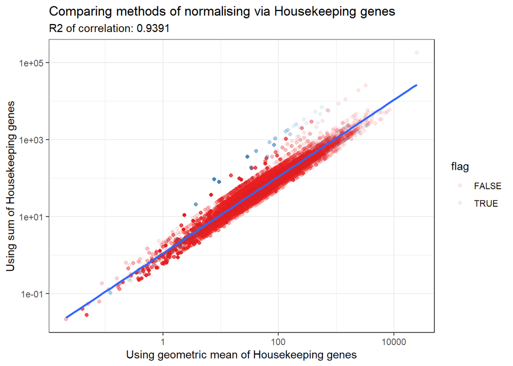

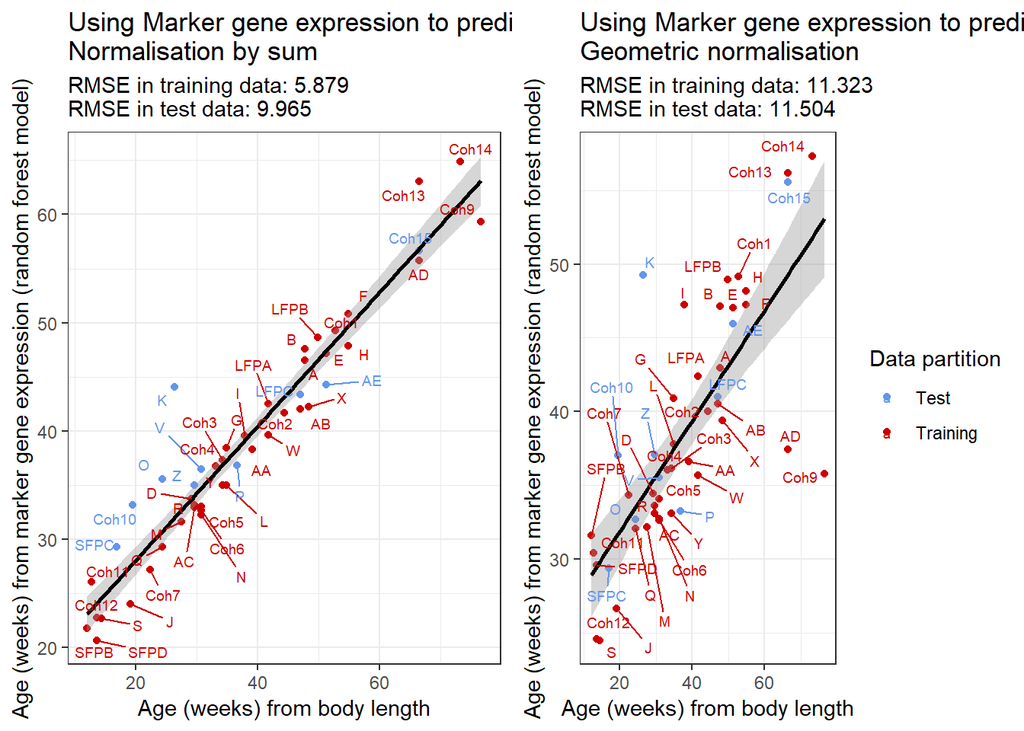

#Expression levels and replicability

Need to establish an appropriate threshold of expression above which replicability is acceptable. Look at the samples for which two Nanostring replicates are available.

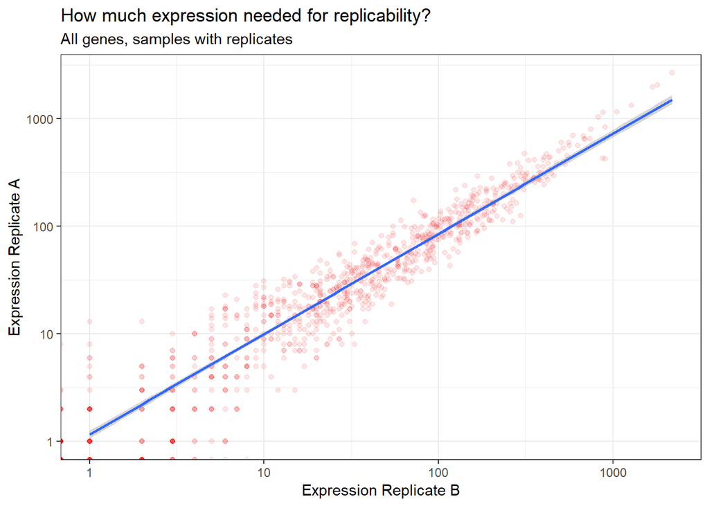

And looking at the residual variation:

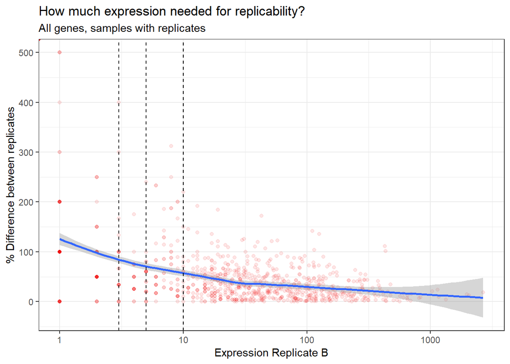

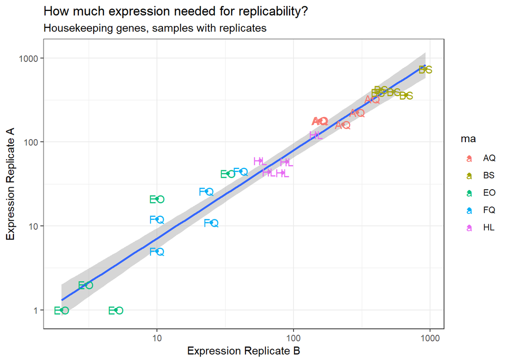

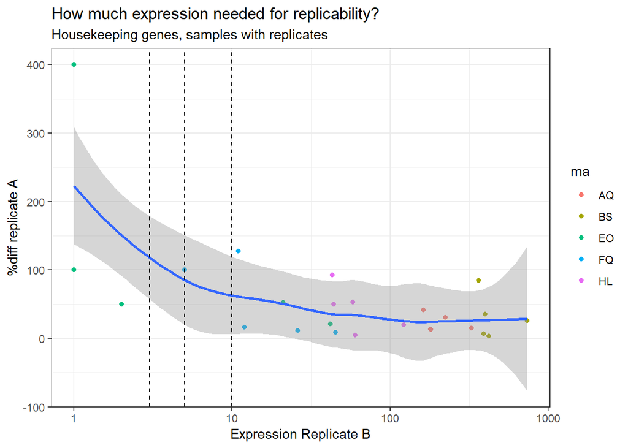

Anywhere above 5-10 reads starts to look somewhat reasonable here.

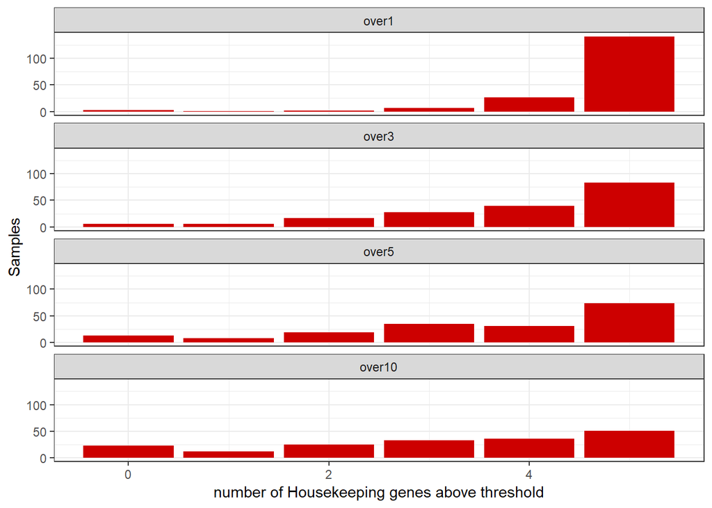

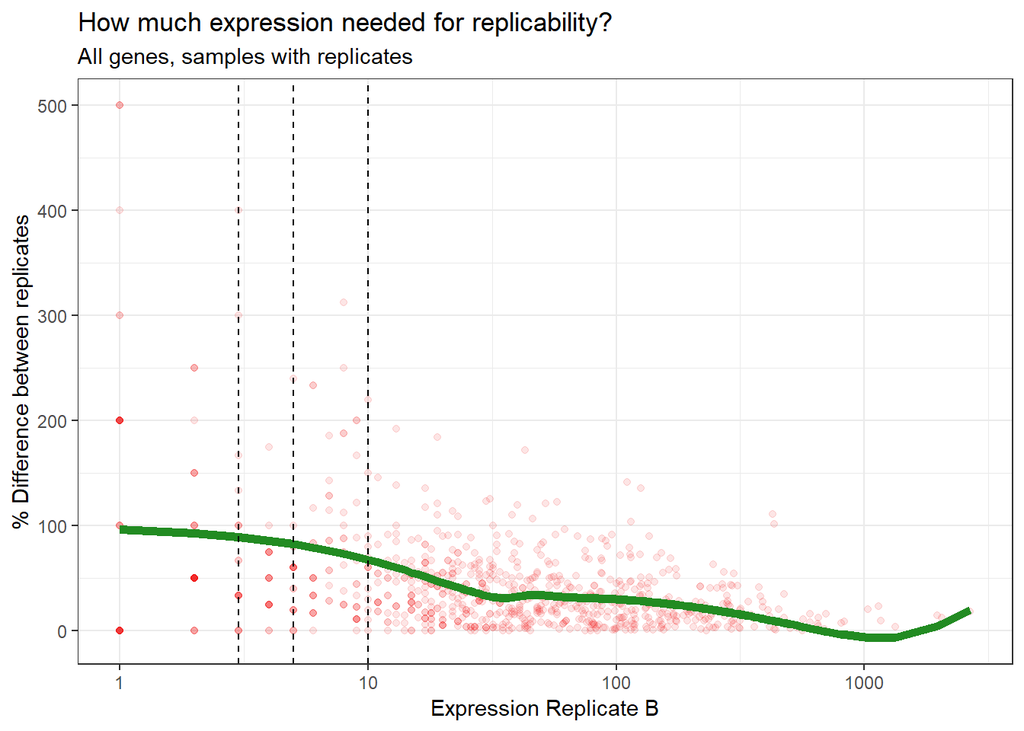

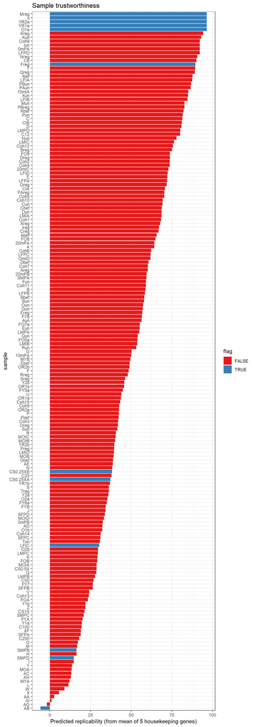

# Housekeeping gene expression

To place this into context, we need to ask how strongly expressed our housekeeping genes are.

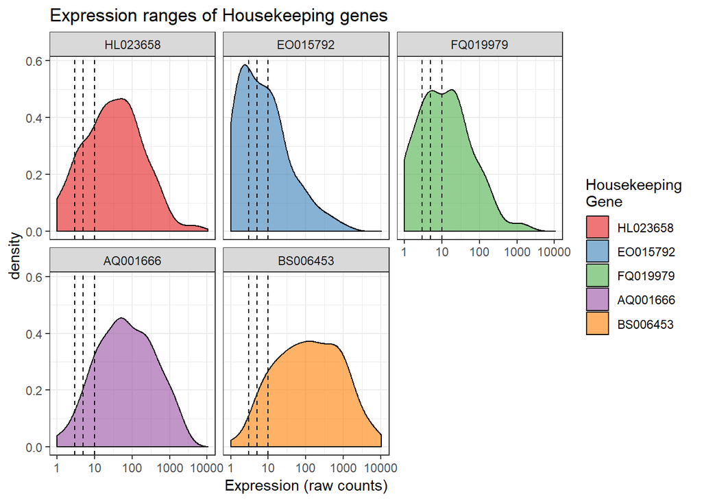

# Housekeeping Gene intercorrelation

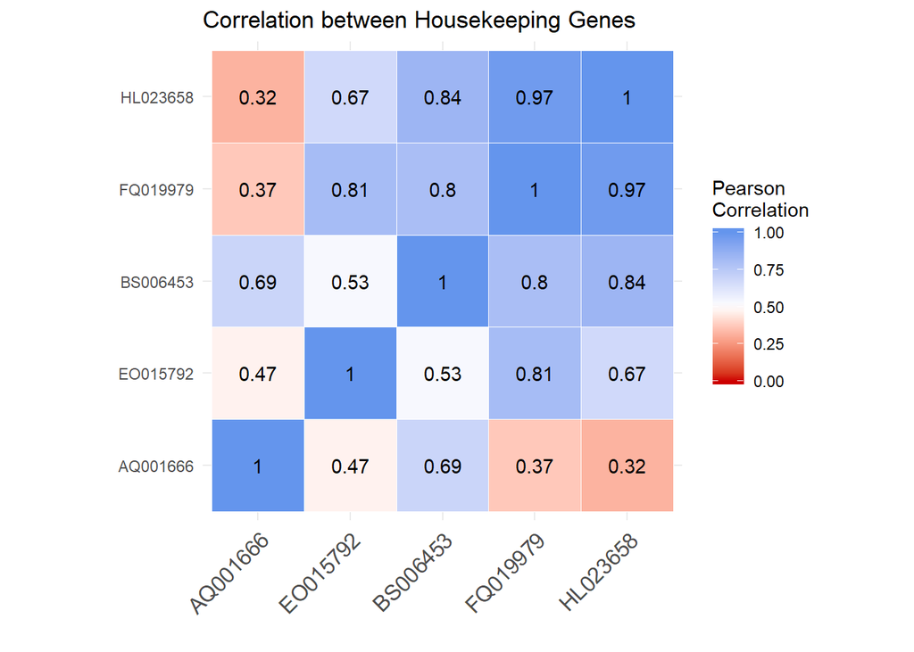

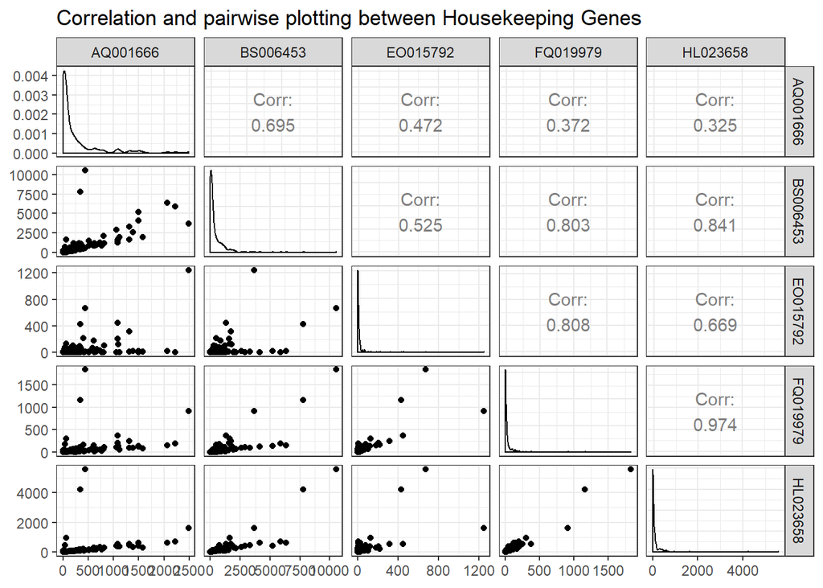